# Computer Practical 1: Introduction to R and plotting with ggplot2

## 11.11 Changing colours

To change the colours of plots, you need to use the intructions “colour” or “fill”, depending what type of plot you have. Colours always have to be in quotation marks, and R recognises the names of most standard colours. Lets make some colourful histograms.

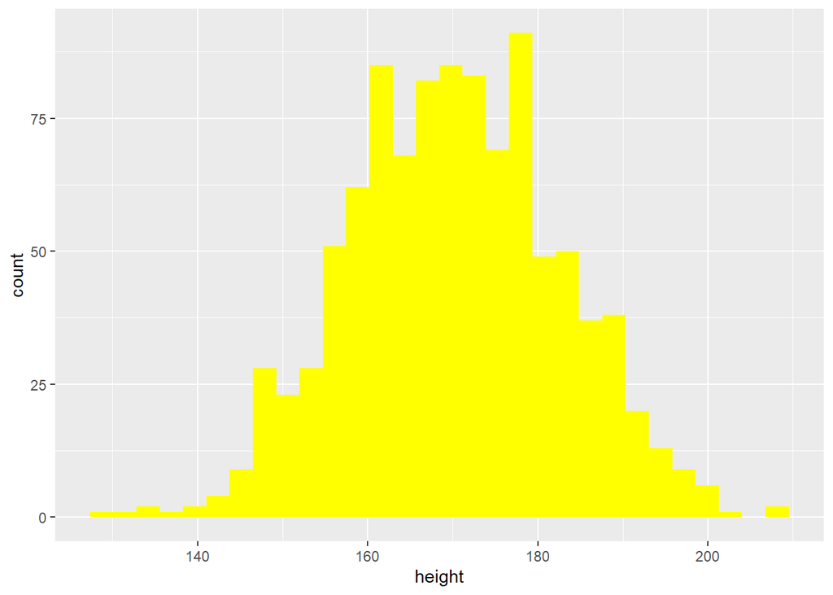

```r
# histogram

# change the colour inside of the bars

ggplot(pirates, aes(x = height))+
  geom_histogram(fill = "yellow")
```

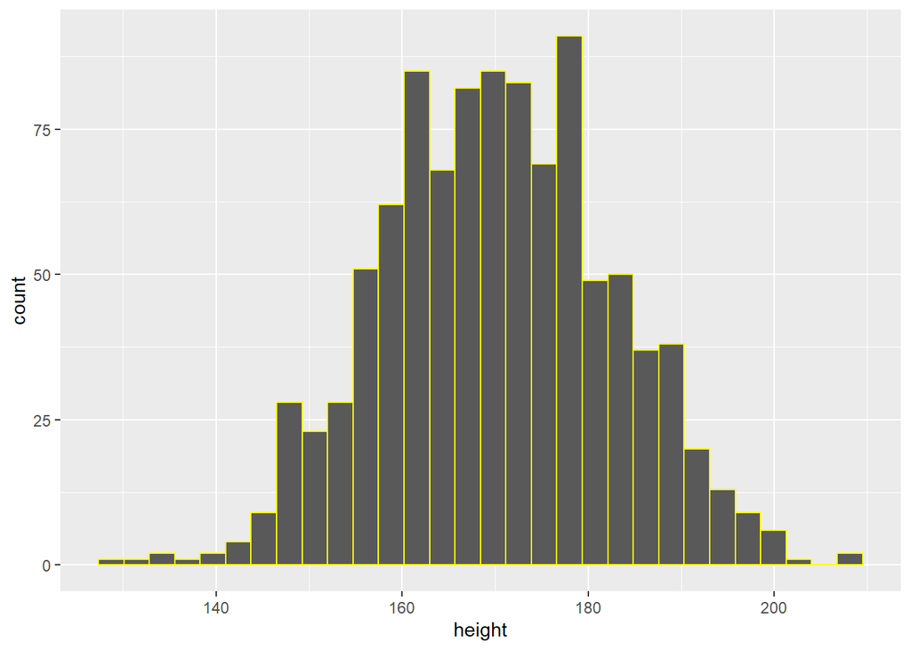

```r
# change the border colour

ggplot(pirates, aes(x = height))+
  geom_histogram(colour = "yellow")
```

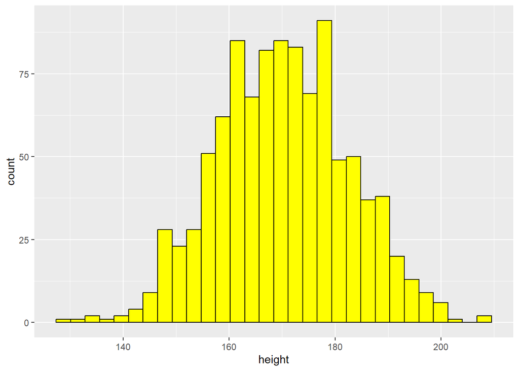

```r
# change border colour and fill colour

ggplot(pirates, aes(x = height))+
  geom_histogram(fill = "yellow", colour = "black")
```

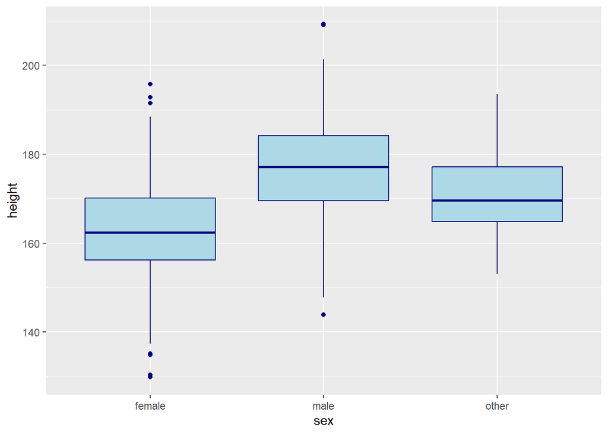

```r
ggplot(pirates, aes(x = sex, y = height))+
  geom_boxplot(fill = "lightblue", colour = "navyblue")
```

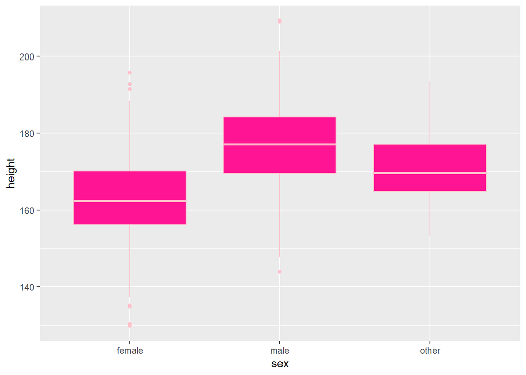

```r
ggplot(pirates, aes(x = sex, y = height))+
  geom_boxplot(fill = "deeppink", colour = "pink")
```

Now lets make some colourful scatterplots. However, note you cant use ‘fill’ on scatterplots - only color!

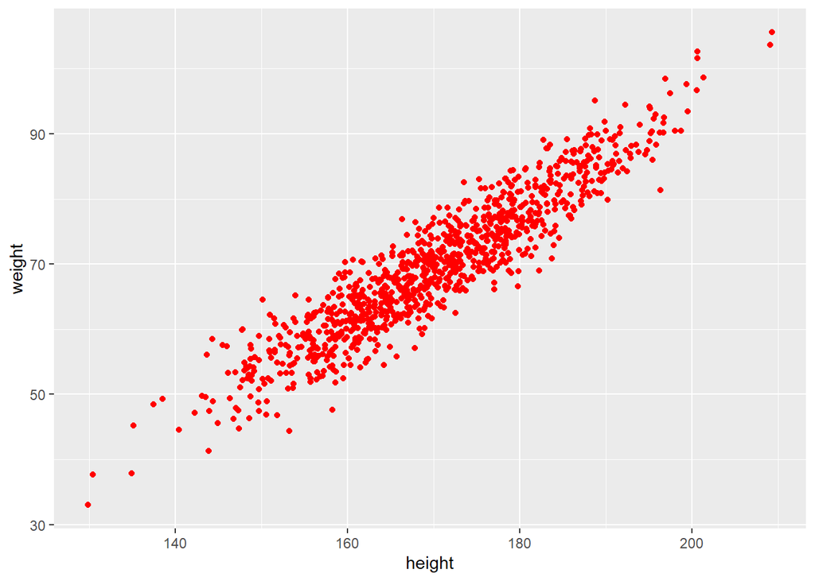

```r
ggplot(data = pirates, aes(x = height, y = weight))+ # data and axes
  geom_point(colour = "red")                            # plot type
```

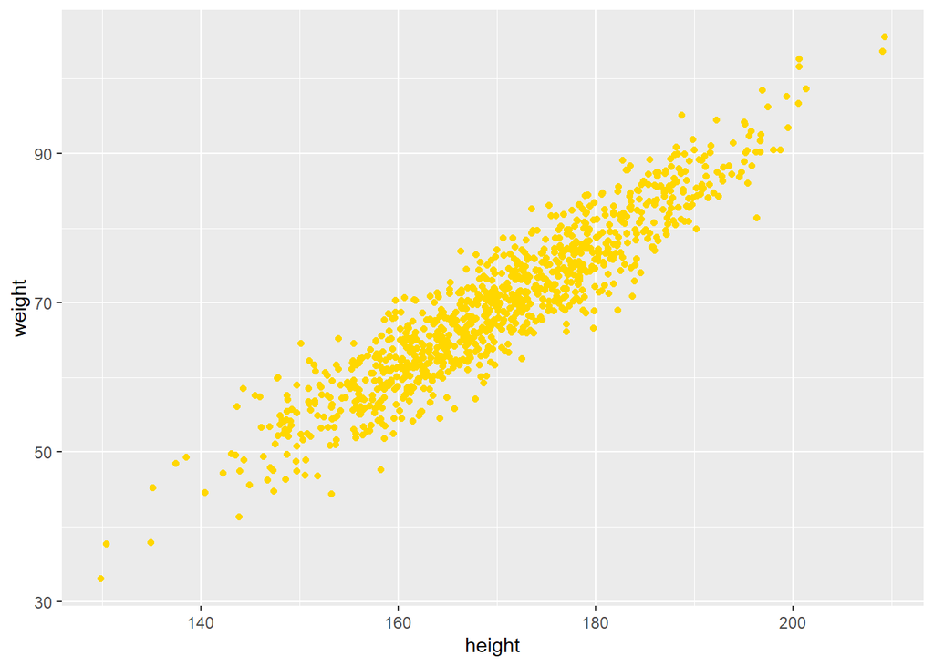

```r
# instead of 'colour', you can also use just 'col' for short

ggplot(data = pirates, aes(x = height, y = weight))+ # data and axes
  geom_point(col = "gold")                            # plot type
```

A non-exhaustive list of colours you can use can be found here: https://r-graph-gallery.com/42-colors-names.html.

# 12 Save your scripts

Before you go home, make sure you save your R scripts by pressing the ‘save’ button. Go to the instructions at the start of the worksheet. If everything is saved, you can access R and the work you have done so far from your laptop.

# 13 Homework

For your homework, you need to finish off this practical in your own time, and in addition do Exercises 10 and 11 below. This will ensure you understand how to make basic plots prior to next week’s computer practical. **You can access your R studio cloud profile from your laptop.**

For your homework, we will use another example dataset, this one on penguin morphology in the Palmer Archipeligo in Antarctica. This dataset is contained within the package palmerpenguins, which you will download and load in order to access the dataset.

```r
install.packages("palmerpenguins") # install package

# You only ever need to install the package once!!
```

```r
library(palmerpenguins) # load package

?palmerpenguins # The ? before a package or function will bring up a description of the the package or function. For functions, the help page provides examples on how the function works.

data(penguins) # load the dataset into your environment

View(penguins) # check out the dataset

str(penguins) # check out variables contained in the dataset
```

```
## tibble [344 x 8] (S3: tbl_df/tbl/data.frame)
##  $ species          : Factor w/ 3 levels "Adelie","Chinstrap",..: 1 1 1 1 1 1 1 1 1 1 ...
##  $ island           : Factor w/ 3 levels "Biscoe","Dream",..: 3 3 3 3 3 3 3 3 3 3 ...
##  $ bill_length_mm   : num [1:344] 39.1 39.5 40.3 NA 36.7 39.3 38.9 39.2 34.1 42 ...
##  $ bill_depth_mm    : num [1:344] 18.7 17.4 18 NA 19.3 20.6 17.8 19.6 18.1 20.2 ...
##  $ flipper_length_mm: int [1:344] 181 186 195 NA 193 190 181 195 193 190 ...
##  $ body_mass_g      : int [1:344] 3750 3800 3250 NA 3450 3650 3625 4675 3475 4250 ...
##  $ sex              : Factor w/ 2 levels "female","male": 2 1 1 NA 1 2 1 2 NA NA ...
##  $ year             : int [1:344] 2007 2007 2007 2007 2007 2007 2007 2007 2007 2007 ...
```

## 13.1 Exercise 10

- Summarise the number of observations the data contains per species (i.e., how many penguins in the dataset are Adelie, how many are Chinstrap, and how many are Gentoo?),

```r
table(penguins$species)
```

```
##
##    Adelie Chinstrap    Gentoo
##       152        68       124
```

```r
# Adelie = 152, Chinstrap = 68, Gentoo = 124
```

- Calculate the mean body weight across all penguins.

```r
summary(penguins$body_mass_g)
```

```
##    Min. 1st Qu.  Median    Mean 3rd Qu.    Max.    NA's
##    2700    3550    4050    4202    4750    6300       2
```

```r
# mean = 4202g
```

## 13.2 Exercise 11

Make a plot that shows the difference in body mass between different penguin species. Change the y axis label to “Body mass (g)” and the x axis label to “Penguin species”. Add the title “Body weight across penguin species”. Colour the boxes dark turquoise (“darkturquoise”).

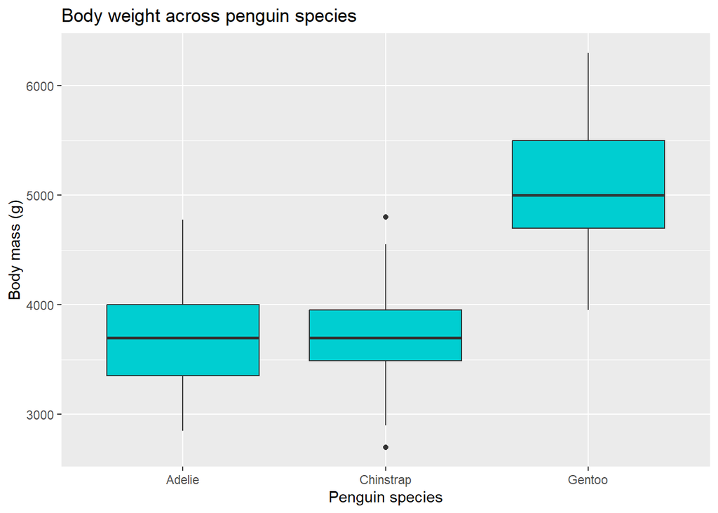

```r
ggplot(penguins, aes(x = species, y = body_mass_g))+
  geom_boxplot(fill = "darkturquoise")+
  ylab("Body mass (g)")+
  xlab("Penguin species")+
  ggtitle("Body weight across penguin species")
```

# 14 Optional: Splitting plots by group (facetting)

If you want to split a plot by a third variable, you can use the layer *facet_wrap()*. Below is an example:

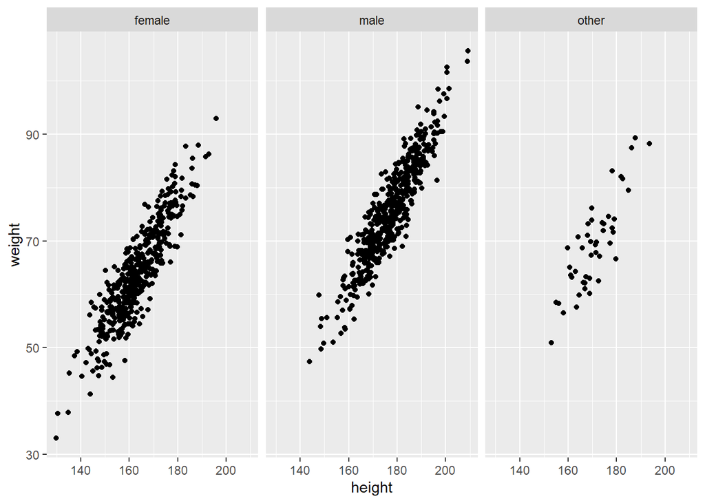

```r
ggplot(data = pirates, aes(x = height, y = weight))+
  geom_point() + # scatter plot
  facet_wrap(~sex) # Seperate the plots by the variable 'sex'
```

# 15 Optional: Changing plot themes

Personally, I don’t love the grey backgound of default ggplot plots. But you can change the theme to change the overall look of the plot. You can do this by addition one of the following layers

- theme_bw()
- theme_minimal()
- theme_dark()
- theme_classic()

Lets try them out. Which do you like best?

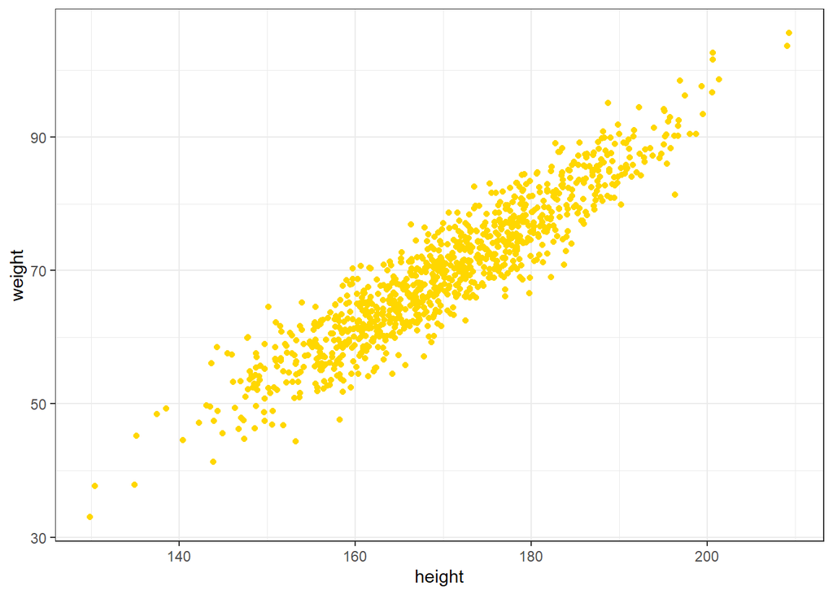

```r
ggplot(data = pirates, aes(x = height, y = weight))+
  geom_point(col = "gold") +
  theme_bw()
```

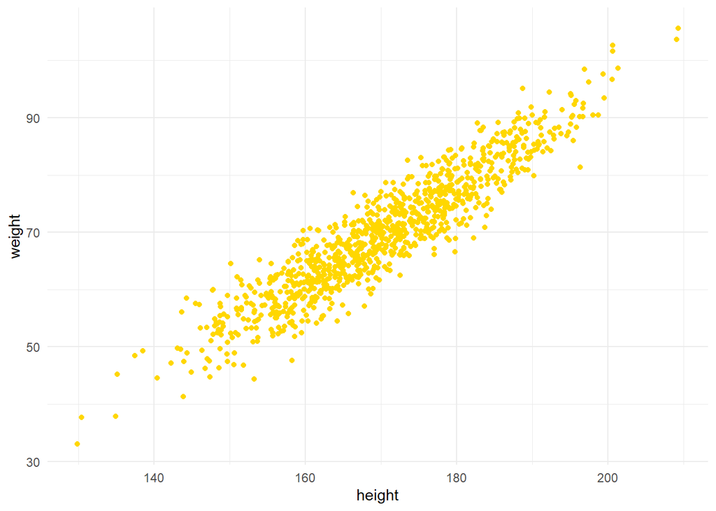

```r
ggplot(data = pirates, aes(x = height, y = weight))+
  geom_point(col = "gold") +
  theme_minimal()
```

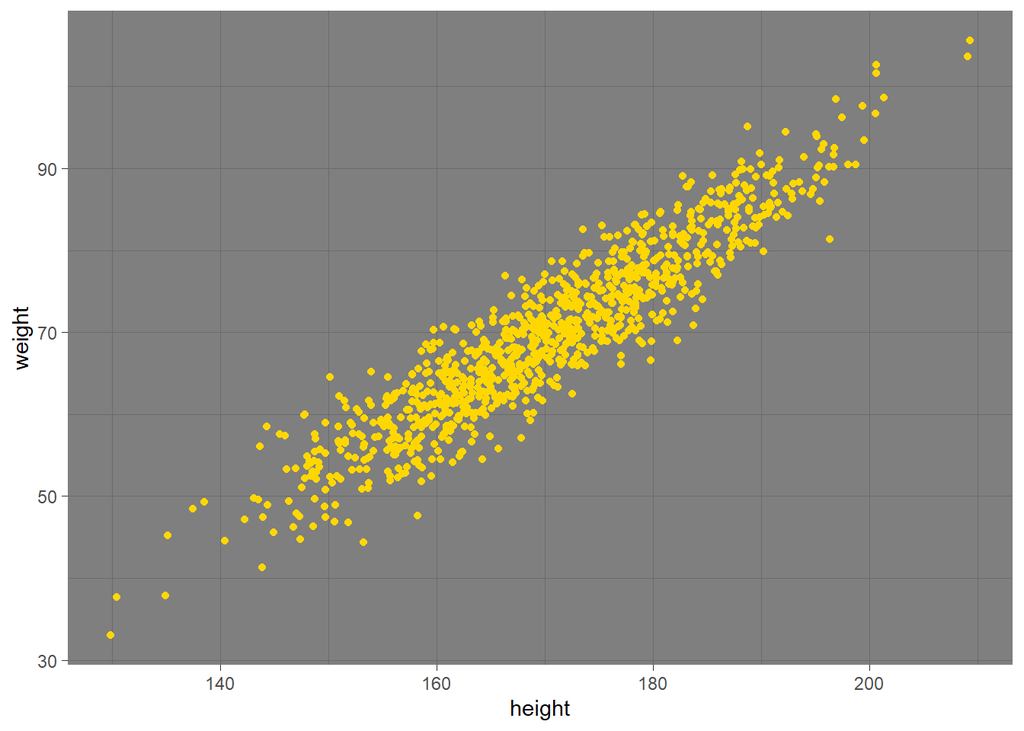

```r
ggplot(data = pirates, aes(x = height, y = weight))+
  geom_point(col = "gold") +
  theme_dark()
```

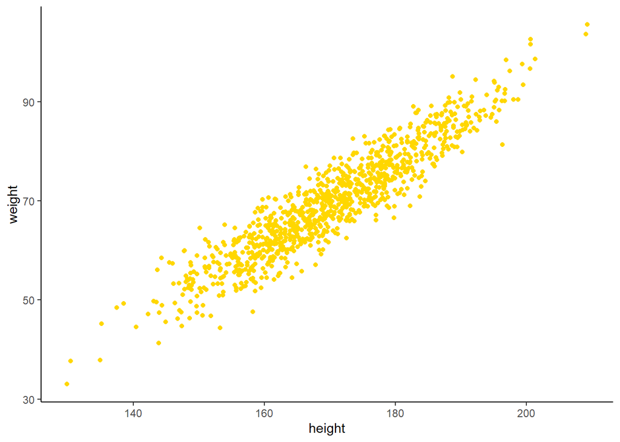

```r
ggplot(data = pirates, aes(x = height, y = weight))+
  geom_point(col = "gold") +
  theme_classic()
```

# 16 Optional: Presenting plots together

There are a number of R packages that are designed to make composite plots. One of the most common ones is *ggpubr.*

To make composite plots, you need to save each plot you want to present together as an object. Below I have made four plots (a bar plot, a histogram, a scatter plot, and a boxplot) and presented them together using the function ggarrange().

```r
install.packages("ggpubr") # install package

# You only need to ever do this once
```

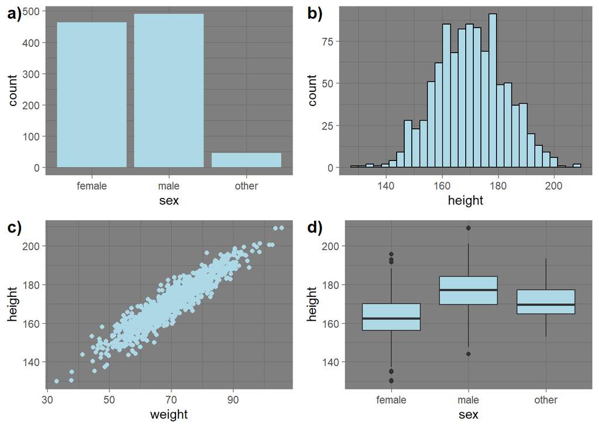

```r
library(ggpubr) # load package

# create the four plots we have been practicing above

barplot <- ggplot(pirates, aes(x = sex))+
  geom_bar(fill = "lightblue")+
  theme_dark()

histogram <- ggplot(pirates, aes(x = height))+
  geom_histogram(fill = "lightblue", col = "black")+
  theme_dark()

scatterplot<- ggplot(pirates, aes(y = height, x = weight))+
  geom_point(col = "lightblue")+
  theme_dark()

boxplot<- ggplot(pirates, aes(x = sex, y = height))+
  geom_boxplot(fill = "lightblue")+
  theme_dark()

# make a composite plot and label a-d.

ggpubr::ggarrange(barplot, histogram, scatterplot, boxplot, labels = c("a)", "b)", "c)", "d)"))
```

## 16.1